# **Содержание проекта**

- Введение
  - Цель исследования
  - Этапы исследования
- [1 Этап] первичный анализ данных
  - Выявленные аномалии в данных
- [2 Этап] Предобработка данных
- [3 Этап] Анализ взаимосвязей
  - 3.1 Взаимосвязь между семейным положением клиента и риском невозврата кредита
  - 3.2 Взаимосвязь между количеством детей клиента и риском невозврата кредита
  - 3.3 Взаимосвязь между уровнем дохода клиента и риском невозврата кредита
  - 3.4 Взаимосвязь между целью кредита и риском невозврата кредита
  - 3.5 Обработка стажа работы и кросс-анализ с семейным положением
  - 3.6 Построение "Портрета рискового заемщика"
- Заключение: Комплексный анализ кредитного риска и ценность для бизнеса

# Введение

В современном мире кредитование является одной из ключевых сфер финансового сектора. Банки и кредитные организации стремятся минимизировать риски невозврата кредитов, разрабатывая модели кредитного скоринга. Одним из факторов, влияющих на способность заемщика выполнять свои обязательства, может быть его семейное положение и количество детей.

Данное исследование направлено на анализ зависимости между возвратом кредита в срок и такими характеристиками заемщика, как семейное положение и число детей. Исследование проводится на основе реальных данных, содержащих информацию о клиентах банка, их доходах, задолженностях и целях кредита.

### Цель исследования

Выявление возможных закономерностей, которые могут быть полезны при построении моделей кредитного скоринга. Полученные выводы помогут банку в принятии более обоснованных решений при выдаче кредитов, что позволит снизить уровень просроченных задолженностей.

### Этапы исследования

1. **Первичный анализ данных**: изучение структуры датасета, выявление пропусков и аномальных значений.
2. **Предобработка данных**: устранение пропусков, обработка дубликатов и приведение данных к единообразному виду.
3. **Анализ взаимосвязей**: графический анализ распределения признаков, выявление закономерностей.

### Используемые инструменты

Исследование будет выполнено в среде Jupyter Notebook с использованием языка программирования Python и популярных библиотек для анализа данных, таких как `Pandas`, `Matplotlib` и `Seaborn`. Это позволит наглядно представить результаты анализа и продемонстрировать уровень владения инструментами анализа данных.

# [1 Этап] Первичный анализ данных

```python
# Импорт необходимых библиотек
import pandas as pd
import numpy as np
import matplotlib.pyplot as plt
import seaborn as sns

pd.set_option('display.float_format', lambda x: f'{x:,.2f}'.replace(',', ' '))

# Загрузка данных
file_path = r"C:\Users\Сэм\Downloads\data.csv"
df = pd.read_csv(file_path)

# Просмотр первых строк
df.head()
```

|  | children | days_employed | dob_years | education | education_id | family_status | family_status_id | gender | income_type | debt | total_income | purpose |
| --- | --- | --- | --- | --- | --- | --- | --- | --- | --- | --- | --- | --- |
| 0 | 1 | -8 437.67 | 42 | высшее | 0 | женат / замужем | 0 | F | сотрудник | 0 | 253 875.64 | покупка жилья |
| 1 | 1 | -4 024.80 | 36 | среднее | 1 | женат / замужем | 0 | F | сотрудник | 0 | 112 080.01 | приобретение автомобиля |
| 2 | 0 | -5 623.42 | 33 | Среднее | 1 | женат / замужем | 0 | M | сотрудник | 0 | 145 885.95 | покупка жилья |
| 3 | 3 | -4 124.75 | 32 | среднее | 1 | женат / замужем | 0 | M | сотрудник | 0 | 267 628.55 | дополнительное образование |
| 4 | 0 | 340 266.07 | 53 | среднее | 1 | гражданский брак | 1 | F | пенсионер | 0 | 158 616.08 | сыграть свадьбу |

```python
df.info()
```

```
<class 'pandas.core.frame.DataFrame'>
RangeIndex: 21525 entries, 0 to 21524
Data columns (total 12 columns):
 #   Column            Non-Null Count  Dtype
---  ------            --------------  -----
 0   children          21525 non-null  int64
 1   days_employed     19351 non-null  float64
 2   dob_years         21525 non-null  int64
 3   education         21525 non-null  object
 4   education_id      21525 non-null  int64
 5   family_status     21525 non-null  object
 6   family_status_id  21525 non-null  int64
 7   gender            21525 non-null  object
 8   income_type       21525 non-null  object
 9   debt              21525 non-null  int64
 10  total_income      19351 non-null  float64
 11  purpose           21525 non-null  object
dtypes: float64(2), int64(5), object(5)
memory usage: 2.0+ MB
```

```python
# Определяем где пропуски
print("\nКоличество пропущенных значений в каждом столбце:")
display(df.isnull().sum())

# Проверяем на дубликаты
print("\nКоличество полных дубликатов в датасете:", df.duplicated().sum())

# Проверяем описательные статистики для числовых столбцов
display(df.describe())

# Проверяем отрицательные значения в числовых столбцах
print("\nОтрицательные значения в числовых столбцах:")
for column in df.select_dtypes(include=['int64', 'float64']).columns:
    if (df[column] < 0).any():
        print(f"- {column}: {df[column].min()} (минимум)")

# Проверяем уникальные значения в категориальных столбцах
print("\nУникальные значения в категориальных столбцах:")
for column in df.select_dtypes(include=['object']).columns:
    print(f"\n{column}:")
    display(df[column].unique())
```

```
Количество пропущенных значений в каждом столбце:
```

```
children               0
days_employed       2174
dob_years              0
education              0
education_id           0
family_status          0
family_status_id       0
gender                 0
income_type            0
debt                   0
total_income        2174
purpose                0
dtype: int64
```

```
Количество полных дубликатов в датасете: 54
```

|  | children | days_employed | dob_years | education_id | family_status_id | debt | total_income |
| --- | --- | --- | --- | --- | --- | --- | --- |
| count | 21 525.00 | 19 351.00 | 21 525.00 | 21 525.00 | 21 525.00 | 21 525.00 | 19 351.00 |
| mean | 0.54 | 63 046.50 | 43.29 | 0.82 | 0.97 | 0.08 | 167 422.30 |
| std | 1.38 | 140 827.31 | 12.57 | 0.55 | 1.42 | 0.27 | 102 971.57 |
| min | -1.00 | -18 388.95 | 0.00 | 0.00 | 0.00 | 0.00 | 20 667.26 |
| 25% | 0.00 | -2 747.42 | 33.00 | 1.00 | 0.00 | 0.00 | 103 053.15 |
| 50% | 0.00 | -1 203.37 | 42.00 | 1.00 | 0.00 | 0.00 | 145 017.94 |
| 75% | 1.00 | -291.10 | 53.00 | 1.00 | 1.00 | 0.00 | 203 435.07 |
| max | 20.00 | 401 755.40 | 75.00 | 4.00 | 4.00 | 1.00 | 2 265 604.03 |

```
Отрицательные значения в числовых столбцах:
- children: -1 (минимум)
- days_employed: -18388.949900568383 (минимум)

Уникальные значения в категориальных столбцах:

education:
```

```
array(['высшее', 'среднее', 'Среднее', 'СРЕДНЕЕ', 'ВЫСШЕЕ',
       'неоконченное высшее', 'начальное', 'Высшее',
       'НЕОКОНЧЕННОЕ ВЫСШЕЕ', 'Неоконченное высшее', 'НАЧАЛЬНОЕ',
       'Начальное', 'Ученая степень', 'УЧЕНАЯ СТЕПЕНЬ', 'ученая степень'],
      dtype=object)
```

```
family_status:
```

```
array(['женат / замужем', 'гражданский брак', 'вдовец / вдова',
       'в разводе', 'Не женат / не замужем'], dtype=object)
```

```
gender:
```

```
array(['F', 'M', 'XNA'], dtype=object)
```

```
income_type:
```

```
array(['сотрудник', 'пенсионер', 'компаньон', 'госслужащий',
       'безработный', 'предприниматель', 'студент', 'в декрете'],
      dtype=object)
```

```
purpose:
```

```
array(['покупка жилья', 'приобретение автомобиля',
       'дополнительное образование', 'сыграть свадьбу',
       'операции с жильем', 'образование', 'на проведение свадьбы',
       'покупка жилья для семьи', 'покупка недвижимости',
       'покупка коммерческой недвижимости', 'покупка жилой недвижимости',
       'строительство собственной недвижимости', 'недвижимость',
       'строительство недвижимости', 'на покупку подержанного автомобиля',
       'на покупку своего автомобиля',
       'операции с коммерческой недвижимостью',
       'строительство жилой недвижимости', 'жилье',
       'операции со своей недвижимостью', 'автомобили',
       'заняться образованием', 'сделка с подержанным автомобилем',
       'получение образования', 'автомобиль', 'свадьба',
       'получение дополнительного образования', 'покупка своего жилья',
       'операции с недвижимостью', 'получение высшего образования',
       'свой автомобиль', 'сделка с автомобилем',
       'профильное образование', 'высшее образование',
       'покупка жилья для сдачи', 'на покупку автомобиля', 'ремонт жилью',
       'заняться высшим образованием'], dtype=object)
```

### **Выявленные аномалии в данных**

#### **1. Пропущенные значения и полные дубликаты**

- `days_employed` (трудовой стаж) → **2174 пропущенных значений**
- `total_income` (ежемесячный доход) → **2174 пропущенных значений**
- **54 строки** полностью дублируются.

*Пропуски требуют анализа: возможно, они связаны с определёнными категориями клиентов и являются неслучайными (например, безработными или пенисонеры).Необходимо удалить дубликаты,так как они могут исказить данные*

### **2. Аномалии в числовых данных**

- `children`: **есть значение `-1`**, что невозможно.
- `days_employed`: **минимальное значение `-18388`**, что означает **отрицательный стаж**.

*Отрицательные значения в `days_employed` и `children` нужно исправить. Возможно, `-1` – это ошибка ввода, а отрицательный стаж связан с ошибкой загрузки данных*

#### **3. Проблемы с категориальными данными**

- `education`: **разные регистры** (например, "среднее", "СРЕДНЕЕ", "Среднее").
- `gender`: есть **"XNA"**, что может быть ошибкой.
- `purpose`: **много дублирующихся формулировок** (например, "на покупку автомобиля" и "свой автомобиль").

*Эти данные нужно привести к единому формату, чтобы избежать дублирования категорий.*

# [2 этап] Предобработка данных

## 2.1 Обработка пропусков и удаление дубликатов

Рассмотрим подробнее в каких строчках допущены пропуски по столбацам `days_employed` и `total_income` и убедимся, что пропуски в одних и тех же строчках, а также определим к какой категории относятся данные клиенты по столбцу `income_type`

```python
#Отберем столбцы с пропущенными значениями
df_with_misses = df[df['days_employed'].isna()]
df_with_misses.info()
df_with_misses.head()
```

```
<class 'pandas.core.frame.DataFrame'>
Index: 2174 entries, 12 to 21510
Data columns (total 12 columns):
 #   Column            Non-Null Count  Dtype
---  ------            --------------  -----
 0   children          2174 non-null   int64
 1   days_employed     0 non-null      float64
 2   dob_years         2174 non-null   int64
 3   education         2174 non-null   object
 4   education_id      2174 non-null   int64
 5   family_status     2174 non-null   object
 6   family_status_id  2174 non-null   int64
 7   gender            2174 non-null   object
 8   income_type       2174 non-null   object
 9   debt              2174 non-null   int64
 10  total_income      0 non-null      float64
 11  purpose           2174 non-null   object
dtypes: float64(2), int64(5), object(5)
memory usage: 220.8+ KB
```

|  | children | days_employed | dob_years | education | education_id | family_status | family_status_id | gender | income_type | debt | total_income | purpose |
| --- | --- | --- | --- | --- | --- | --- | --- | --- | --- | --- | --- | --- |
| 12 | 0 | NaN | 65 | среднее | 1 | гражданский брак | 1 | M | пенсионер | 0 | NaN | сыграть свадьбу |
| 26 | 0 | NaN | 41 | среднее | 1 | женат / замужем | 0 | M | госслужащий | 0 | NaN | образование |
| 29 | 0 | NaN | 63 | среднее | 1 | Не женат / не замужем | 4 | F | пенсионер | 0 | NaN | строительство жилой недвижимости |
| 41 | 0 | NaN | 50 | среднее | 1 | женат / замужем | 0 | F | госслужащий | 0 | NaN | сделка с подержанным автомобилем |
| 55 | 0 | NaN | 54 | среднее | 1 | гражданский брак | 1 | F | пенсионер | 1 | NaN | сыграть свадьбу |

```python
#Определим к какому тиму занятости относятся пропуски и какую долю они занимают от общего числа строк
icnome_type_with_misses = df.groupby('income_type').agg(
    total_rows=('income_type', 'count'),  # Всего строк в группе
    missing_rows=('days_employed', lambda y: y.isna().sum()),  # Количество строк с NaN
).assign(missing_ratio=lambda x: x.missing_rows*100 / x.total_rows).reset_index().sort_values(by = 'missing_rows', ascending = False) #Доля

icnome_type_with_misses
```

|  | income_type | total_rows | missing_rows | missing_ratio |
| --- | --- | --- | --- | --- |
| 6 | сотрудник | 11119 | 1105 | 9.94 |
| 3 | компаньон | 5085 | 508 | 9.99 |
| 4 | пенсионер | 3856 | 413 | 10.71 |
| 2 | госслужащий | 1459 | 147 | 10.08 |
| 5 | предприниматель | 2 | 1 | 50.00 |
| 0 | безработный | 2 | 0 | 0.00 |
| 1 | в декрете | 1 | 0 | 0.00 |
| 7 | студент | 1 | 0 | 0.00 |

Пропущенные значения занимают 10% от общего числа данных,а также не являются зависимыми от типа занятости,можем удалить эти пропуски с целью не искажать данные исследования. Сравним статистические показатели данных до и после удаления пропусков

```python
# Удаляем пропуски
df_cleaned = df.dropna(subset=['total_income'])

df_cleaned.describe()
```

|  | children | days_employed | dob_years | education_id | family_status_id | debt | total_income |
| --- | --- | --- | --- | --- | --- | --- | --- |
| count | 19 351.00 | 19 351.00 | 19 351.00 | 19 351.00 | 19 351.00 | 19 351.00 | 19 351.00 |
| mean | 0.54 | 63 046.50 | 43.26 | 0.82 | 0.97 | 0.08 | 167 422.30 |
| std | 1.37 | 140 827.31 | 12.58 | 0.55 | 1.42 | 0.27 | 102 971.57 |
| min | -1.00 | -18 388.95 | 0.00 | 0.00 | 0.00 | 0.00 | 20 667.26 |
| 25% | 0.00 | -2 747.42 | 33.00 | 1.00 | 0.00 | 0.00 | 103 053.15 |
| 50% | 0.00 | -1 203.37 | 42.00 | 1.00 | 0.00 | 0.00 | 145 017.94 |
| 75% | 1.00 | -291.10 | 53.00 | 1.00 | 1.00 | 0.00 | 203 435.07 |
| max | 20.00 | 401 755.40 | 75.00 | 4.00 | 4.00 | 1.00 | 2 265 604.03 |

```python
df.describe()
```

|  | children | days_employed | dob_years | education_id | family_status_id | debt | total_income |
| --- | --- | --- | --- | --- | --- | --- | --- |
| count | 21 525.00 | 19 351.00 | 21 525.00 | 21 525.00 | 21 525.00 | 21 525.00 | 19 351.00 |
| mean | 0.54 | 63 046.50 | 43.29 | 0.82 | 0.97 | 0.08 | 167 422.30 |
| std | 1.38 | 140 827.31 | 12.57 | 0.55 | 1.42 | 0.27 | 102 971.57 |
| min | -1.00 | -18 388.95 | 0.00 | 0.00 | 0.00 | 0.00 | 20 667.26 |
| 25% | 0.00 | -2 747.42 | 33.00 | 1.00 | 0.00 | 0.00 | 103 053.15 |
| 50% | 0.00 | -1 203.37 | 42.00 | 1.00 | 0.00 | 0.00 | 145 017.94 |
| 75% | 1.00 | -291.10 | 53.00 | 1.00 | 1.00 | 0.00 | 203 435.07 |
| max | 20.00 | 401 755.40 | 75.00 | 4.00 | 4.00 | 1.00 | 2 265 604.03 |

После удаления пропусков статистические показатели почти не изменяются от первоначальных

```python
df = df.dropna()
```

```python
df = df.drop_duplicates().reset_index(drop=True)
```

## **2.2 Обработка аномалий в числовых данных**

В ходе анализа выявлены следующие аномальные значения:

- В `children` есть значение `-1`, что невозможно. Вероятно, это ошибка ввода или сбой при загрузке данных.
- В `children` также встречается значение `20`, что выглядит нереалистично. Возможно, также ошибка ввода данных, заменим 20 на 2.
- В `days_employed` обнаружены отрицательные значения, что указывает на возможные проблемы при выгрузке. Следует уточнить у коллег выгружающих данных или отвечающих за их качество, в чем могут быть проблемы. Также максимальное значение дней трудового стажа составляет 401 755 дней, чего также быть не может. Данный фактор является проблематичным в плане качества данных, поэтому не стоит их учитывать, обработаем в последующем.

Для исправления:

- Заменим `-1` в `children` на `1`, так как наиболее вероятная причина — ошибка ввода.
- Проверим значение `20` в `children` и заменим выброс.

```python
# Замена -1 в children на 1
df['children'] = df['children'].replace(-1, 1)

# Проверяем количество значений 20 в children
df['children'].value_counts()
```

```
children
0     12710
1      4387
2      1851
3       294
20       67
4        34
5         8
Name: count, dtype: int64
```

```python
# Заменяем 20 на медианное значение по столбцу, если таких значений немного
df['children'] = df['children'].replace(20, 2)

# Проверяем результат
df['children'].value_counts()
```

```
children
0    12710
1     4387
2     1918
3      294
4       34
5        8
Name: count, dtype: int64
```

## **2.3 Обработка проблем с категориальными данными**

Выявлены следующие проблемы:

- `education` содержит дубликаты из-за разного регистра (например, "среднее", "СРЕДНЕЕ", "Среднее").
- `gender` содержит значение `"XNA"`, что не соответствует стандартным обозначениям пола.
- `purpose` содержит дублирующиеся формулировки, которые можно сгруппировать.

Для исправления:

- Приведем столбец `education` к единому регистру
- Удалим строки, где `gender` равен `"XNA"`, если их окажется крайне мало, и они не повлияют на общий анализ.
- Создадим новый столбец `purpose_category`, в котором будем объединять цели кредита в основные группы:
  - **Операции с автомобилем** (например, "покупка автомобиля", "на машину")
  - **Операции с недвижимостью** (например, "покупка недвижимости", "ремонт жилья")
  - **Получение образования** (например, "на образование", "решил заняться образованием")
  - **Проведение свадьбы** (например, "свадьба")

```python
# Приведение education к единому регистру (первая буква заглавная, остальные строчные), выведем результат
df['education'] = df['education'].str.capitalize()
df['education'].value_counts()
```

```
education
Среднее                13693
Высшее                  4716
Неоконченное высшее      675
Начальное                261
Ученая степень             6
Name: count, dtype: int64
```

```python
# Проверим количество XNA и удалим в случае, если подобных отметок мало
display(df['gender'].value_counts())
df = df[df['gender'] != 'XNA']
```

```
gender
F      12752
M       6598
XNA        1
Name: count, dtype: int64
```

```python
# Функция для категоризации целей кредита
def categorize_purpose(purpose):
    if 'автомобил' in purpose:
        return 'операции с автомобилем'
    elif 'недвиж' in purpose or 'жиль' in purpose:
        return 'операции с недвижимостью'
    elif 'образован' in purpose:
        return 'получение образования'
    elif 'свадьб' in purpose:
        return 'проведение свадьбы'
    return 'другое'

# Создание нового столбца с категориями целей кредита
df['purpose_category'] = df['purpose'].apply(categorize_purpose)

# Проверяем распределение новых категорий
df['purpose_category'].value_counts()
```

```
purpose_category
операции с недвижимостью    9757
операции с автомобилем      3897
получение образования       3597
проведение свадьбы          2099
Name: count, dtype: int64
```

# [3 этап] Анализ взаимосвязей

## **3.1 взаимосвязь между семейным положением клиента и риском невозврата кредита**

Для наглядного представления и глубокого понимания взаимосвязи между семейным положением клиента и риском невозврата кредита, мы начнем с построения столбчатой диаграммы. Эта диаграмма визуализирует долю должников для каждой категории семейного статуса, что позволит быстро выявить наиболее и наименее рискованные сегменты.

```
Доля должников по семейному положению:
           family_status  доля_должников  количество_клиентов
0  Не женат / не замужем            0.10                 2525
3       гражданский брак            0.09                 3734
4        женат / замужем            0.08                11143
1              в разводе            0.07                 1083
2         вдовец / вдова            0.06                  865
------------------------------
```

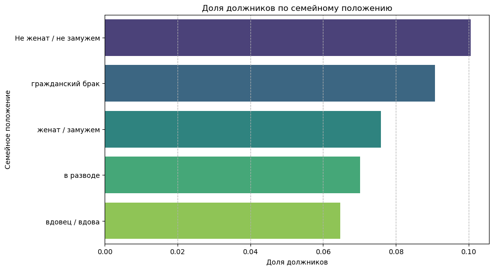

```python
# Рассчитаем долю должников для каждой категории семейного положения
family_status_risk = df.groupby('family_status')['debt'].agg(['mean', 'count']).reset_index()
family_status_risk = family_status_risk.rename(columns={'mean': 'доля_должников', 'count': 'количество_клиентов'})

# Отсортируем для наглядности по доле должников
family_status_risk = family_status_risk.sort_values(by='доля_должников', ascending=False)

print("\nДоля должников по семейному положению:")
print(family_status_risk)
print("-" * 30)

# Визуализация
plt.figure(figsize=(10, 6))
sns.barplot(x='доля_должников', y='family_status', data=family_status_risk, palette='viridis')
plt.title('Доля должников по семейному положению')
plt.xlabel('Доля должников')
plt.ylabel('Семейное положение')
plt.grid(axis='x', linestyle='--') # Добавим сетку для лучшего восприятия значений

plt.show()
```

### Промежуточный вывод: Анализ зависимости невозврата кредита от семейного положения

Анализ зависимости доли должников от семейного положения выявил следующие закономерности:

- **Наиболее высокий процент невозврата кредитов наблюдается среди клиентов со статусом "Не женат / не замужем" (10%) и "гражданский брак" (9%)**. Эти группы, вероятно, требуют более тщательной оценки кредитоспособности.
- **Клиенты со статусом "женат / замужем" демонстрируют более низкий процент невозврата (8%)**. Это может быть связано с большей финансовой стабильностью и ответственностью, присущей людям в официальном браке.
- **Наименее рискованными группами являются "вдовец / вдова" (6%) и "в разводе" (7%)**. Несмотря на возможные прошлые потрясения, эти категории показывают высокую надежность в отношении кредитных обязателх клиентов.

## **3.2 взаимосвязь между количеством детей клиента и риском невозврата кредита**

Мы проанализируем, как количество детей у клиента влияет на вероятность невозврата кредита. Этот фактор может быть значимым при оценке финансовой стабильности и ответственности заемщика. Мы рассчитаем долю должников для каждой категории по количеству детей и визуализируем полученные результаты.

```
Доля должников по количеству детей:
   children  доля_должников  количество_клиентов
2         2            0.10                 1918
1         1            0.09                 4387
4         4            0.09                   34
0         0            0.07                12709
3         3            0.07                  294
5         5            0.00                    8
------------------------------
```

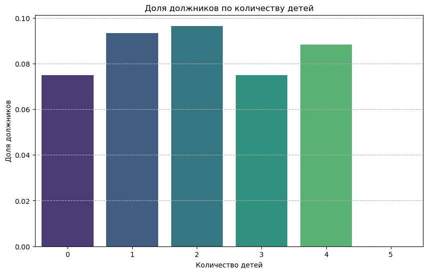

```python
children_risk = df.groupby('children')['debt'].agg(['mean', 'count']).reset_index()
children_risk = children_risk.rename(columns={'mean': 'доля_должников', 'count': 'количество_клиентов'})

# Отсортируем для наглядности по доле должников (сортируем по убыванию, чтобы самые рискованные были сверху)
# Для вертикальной диаграммы сортировка менее критична для читаемости, но можно сохранить для консистентности вывода таблицы.
children_risk = children_risk.sort_values(by='доля_должников', ascending=False)

print("\nДоля должников по количеству детей:")
print(children_risk)
print("-" * 30)

# Визуализация (X и Y поменяны местами обратно, чтобы дети были по X, а доля по Y)
plt.figure(figsize=(10, 6))
sns.barplot(x='children', y='доля_должников', data=children_risk, palette='viridis')
plt.title('Доля должников по количеству детей')
plt.xlabel('Количество детей')
plt.ylabel('Доля должников')
plt.grid(axis='y', linestyle='--') # Добавим сетку для лучшего восприятия значений по Y
plt.show()
```

### Промежуточный вывод: Интерпретация доли должников по количеству детей

На основе представленных данных о доле должников по количеству детей можно сделать следующие наблюдения:

- **Наибольший процент невозврата (10%) наблюдается среди клиентов, имеющих 2 ребенка.** Это может указывать на то, что наличие двух детей увеличивает финансовую нагрузку на семью, что потенциально влияет на способность своевременно погашать кредиты.
- **Клиенты с 1 ребенком и с 4 детьми показывают чуть меньший, но все еще относительно высокий процент невозврата (9%).** Однако стоит отметить, что группа с 4 детьми крайне малочисленна (всего 34 клиента), что делает этот показатель менее статистически значимым и более подверженным случайным флуктуациям.
- **Наиболее низкий процент невозврата (7%) зафиксирован у клиентов без детей (0) и у клиентов с 3 детьми.** Группа без детей является самой многочисленной (12709 клиентов), что делает этот вывод очень надежным. Низкий процент у клиентов с 3 детьми (294 клиента) также примечателен, хотя и на меньшей выборке. Возможно, это свидетельствует о более зрелом финансовом планировании или поддержке в многодетных семьях.
- **Группа клиентов с 5 детьми показывает 0% невозврата, но ее размер крайне мал (всего 8 клиентов).** Это значение не является статистически значимым и не может служить надежной основой для выводов. Такие группы требуют дополнительного исследования или объединения с более крупными категориями (например, "4+ детей").

**Выводы для бизнеса:**

Данный анализ подчеркивает важность количества детей как фактора кредитного риска. Банку стоит обратить особое внимание на следующие аспекты:

- **Сегмент клиентов с 2 детьми** представляет собой группу повышенного риска. Возможно, для них стоит применять более строгие критерии оценки или предлагать кредитные продукты с более консервативными условиями.
- **Клиенты без детей** являются наиболее многочисленной и одной из самых надежных групп с точки зрения возврата кредитов. Это может быть целевой сегмент для активного привлечения.
- **Малочисленные категории (4 и 5 детей)** не дают достаточной статистики для однозначных выводов. Для более точной оценки их рисков требуется либо больше данных, либо объединение этих групп с соседними категориями (например, '3+ детей') для получения более репрезентативной выборки.

## **3.3 взаимосвязь между уровнем дохода клиента и риском невозврата кредита**

Уровень дохода является одним из наиболее критичных факторов при оценке кредитоспособности. На этом этапе мы проанализируем взаимосвязь между доходом клиента и риском невозврата кредита. Поскольку `total_income` является непрерывной переменной, для удобства анализа и визуализации мы сначала категоризируем доход.

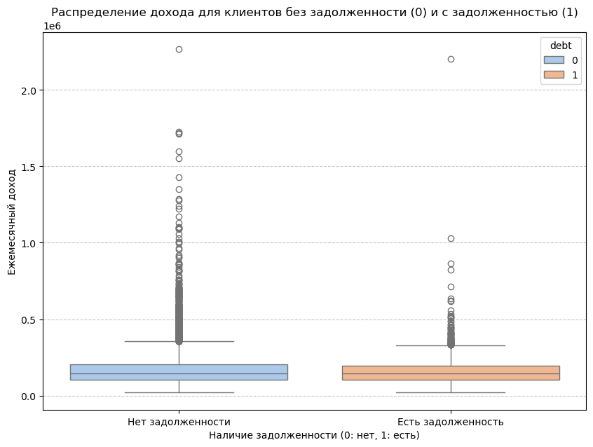

```
Доля должников по категориям дохода:
  income_category  доля_должников  количество_клиентов
2         Высокий            0.09                 4837
1         Средний            0.09                 4837
0          Низкий            0.08                 4838
3   Очень высокий            0.07                 4838
------------------------------
```

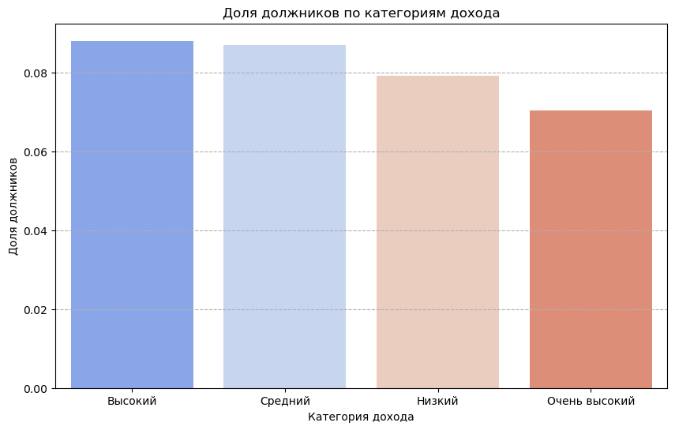

```python
# Создание категорий дохода
# Определим границы для категорий дохода на основе квантилей, чтобы обеспечить сбалансированное распределение.
# Можно также использовать экспертные знания для определения границ (например, по уровню МРОТ, средней зарплаты).
income_bins = [0, df['total_income'].quantile(0.25), df['total_income'].quantile(0.5),
               df['total_income'].quantile(0.75), df['total_income'].max()]
income_labels = ['Низкий', 'Средний', 'Высокий', 'Очень высокий']

df['income_category'] = pd.cut(df['total_income'], bins=income_bins, labels=income_labels, include_lowest=True, right=True)

# 3. Визуализация Box Plot
# Создадим Box Plot для сравнения распределения дохода между должниками и недолжниками.
plt.figure(figsize=(10, 7))
sns.boxplot(x='debt', y='total_income', data=df, palette='pastel', hue='debt')
plt.title('Распределение дохода для клиентов без задолженности (0) и с задолженностью (1)')
plt.xlabel('Наличие задолженности (0: нет, 1: есть)')
plt.ylabel('Ежемесячный доход')
plt.xticks([0, 1], ['Нет задолженности', 'Есть задолженность'])
plt.grid(axis='y', linestyle='--', alpha=0.7)
plt.show()

# Дополнительно: Рассчитаем долю должников по категориям дохода (для таблицы)
income_category_risk = df.groupby('income_category')['debt'].agg(['mean', 'count']).reset_index()
income_category_risk = income_category_risk.rename(columns={'mean': 'доля_должников', 'count': 'количество_клиентов'})
income_category_risk = income_category_risk.sort_values(by='доля_должников', ascending=False)

print("\nДоля должников по категориям дохода:")
print(income_category_risk)
print("-" * 30)

# Визуализация доли должников по категориям дохода (базовая для сравнения)
plt.figure(figsize=(10, 6))
sns.barplot(x='income_category', y='доля_должников', data=income_category_risk, palette='coolwarm',
            order=income_category_risk['income_category']) # Убедимся, что порядок категорий соответствует сортировке
plt.title('Доля должников по категориям дохода')
plt.xlabel('Категория дохода')
plt.ylabel('Доля должников')
plt.grid(axis='y', linestyle='--')
plt.show()
```

### Промежуточный вывод: Анализ зависимости невозврата кредита от уровня дохода

На основе агрегированных данных по категориям дохода, мы выявили следующие закономерности в поведении заемщиков:

- **Наименьший риск невозврата (7% должников) наблюдается среди клиентов с "Очень высоким" доходом.** Это подтверждает общепринятую гипотезу о том, что люди с наибольшими финансовыми возможностями являются самыми надежными заемщиками.
- **Удивительно, но категории "Высокий" и "Средний" доход демонстрируют относительно высокий процент невозврата (9% должников).** Это требует дальнейшего изучения. Возможно, эти клиенты более склонны брать крупные кредиты или имеют сложную финансовую нагрузку, что делает их уязвимыми перед непредвиденными обстоятельствами.
- **Клиенты с "Низким" доходом показывают более низкий процент невозврата (8% должников), чем "Средний" и "Высокий" доход.** Это контринтуитивное наблюдение может быть связано с тем, что банк уже применяет более строгие критерии для этой группы, выдавая кредиты только наиболее надежным представителям, или же эти клиенты более тщательно планируют свои траты и ответственно подходят к погашению долгов.

**Выводы для бизнеса:**

Данный анализ предполагает, что зависимость между доходом и риском невозврата кредита не является простой линейной. Банку следует учесть эти особенности при разработке стратегий:

- **Пересмотр скоринговых моделей:** Важно не просто учитывать доход, но и, возможно, применять более сложные правила или дополнительные проверки для клиентов со "Средним" и "Высоким" доходом.
- **Дифференциация предложений:** Для клиентов с "Очень высоким" доходом можно продолжать предлагать наиболее привлекательные условия. Для группы "Низкого" дохода, несмотря на их кажущуюся надежность по этим данным, следует поддерживать осторожный подход, но при этом можно изучить их финансовое поведение для выявления успешных паттернов.
- **Глубокий анализ сегментов:** Рекомендуется провести более детальный анализ финансового поведения клиентов из категорий "Средний" и "Высокий" доход, чтобы понять истинные причины повышенного уровня невозврата и разработать адресные меры по снижению риска.

## **3.4 взаимосвязь между целью кредита и риском невозврата кредита**

Цель, ради которой берется кредит, является важным показателем потенциального риска. Различные типы кредитов могут быть связаны с разным уровнем ответственности и финансовой отдачи, что влияет на вероятность их своевременного погашения. На этом этапе мы проанализируем, как цель кредита `purpose` коррелирует с невозвратом.

```
Доля должников по категориям целей кредита:
           purpose_category  доля_должников  количество_клиентов
0    операции с автомобилем            0.09                 3897
2     получение образования            0.09                 3597
3        проведение свадьбы            0.08                 2099
1  операции с недвижимостью            0.07                 9757
------------------------------
```

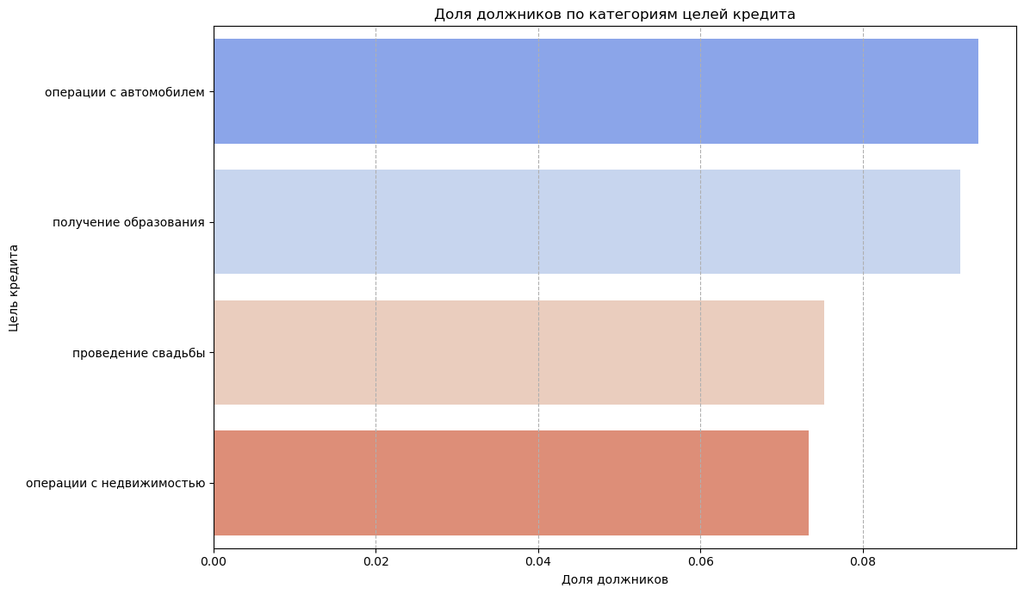

```python
purpose_risk = df.groupby('purpose_category')['debt'].agg(['mean', 'count']).reset_index()
purpose_risk = purpose_risk.rename(columns={'mean': 'доля_должников', 'count': 'количество_клиентов'})

# Отсортируем для наглядности по доле должников
purpose_risk = purpose_risk.sort_values(by='доля_должников', ascending=False)

print("\nДоля должников по категориям целей кредита:")
print(purpose_risk)
print("-" * 30)

# 4. Визуализация
plt.figure(figsize=(12, 7))
sns.barplot(x='доля_должников', y='purpose_category', data=purpose_risk, palette='coolwarm')
plt.title('Доля должников по категориям целей кредита')
plt.xlabel('Доля должников')
plt.ylabel('Цель кредита')
plt.grid(axis='x', linestyle='--')
plt.tight_layout() # Улучшение для избежания обрезания меток
plt.show()
```

### Промежуточный вывод: Анализ зависимости невозврата кредита от цели кредита

На основе предоставленных данных о доле должников по категориям целей кредита, мы выявили следующие закономерности:

- **Наиболее высокий риск невозврата (9% должников) ассоциируется с кредитами на "операции с автомобилем" и "получение образования".**
  - Кредиты на автомобиль могут быть связаны с покупкой актива, который со временем обесценивается, а также с дополнительными расходами на обслуживание.
  - Кредиты на образование, хотя и являются инвестицией, не приносят немедленного финансового дохода и могут создавать долговую нагрузку в период обучения или поиска работы.
- **Средний риск невозврата (8% должников) наблюдается по кредитам на "проведение свадьбы".** Это крупное, но одноразовое событие, которое не генерирует доход, и заемщики могут недооценивать долгосрочную нагрузку после торжества.
- **Наиболее низкий риск невозврата (7% должников) связан с "операциями с недвижимостью".** Это самая многочисленная категория кредитов, что делает вывод особенно надежным. Низкий риск по ипотеке или кредитам на жилье часто объясняется наличием ценного залога, строгим скорингом при выдаче таких кредитов и высокой мотивацией клиентов к своевременным выплатам по жизненно важным обязательствам.

**Выводы для бизнеса:**

Данный анализ позволяет банку оптимизировать свои кредитные продукты и стратегии рисковой оценки с учетом целей кредитования:

1. **Приоритизация рисков по цели:**
   - **Высокорисковые цели**: Банку стоит проявлять повышенную осторожность при выдаче кредитов на **автомобиль**. Возможно, для этих целей следует применять более строгие критерии скоринга, требовать больший первоначальный взнос, предлагать более высокие процентные ставки или рекомендовать страхование.
   - **Низкорисковые цели**: Кредиты на **операции с недвижимостью** являются наиболее надежными. Банк может рассматривать возможность предложения более выгодных условий для привлечения клиентов на эти виды кредитов, поскольку они связаны с меньшим риском.
2. **Продуктовая стратегия:**
   - Можно разработать специализированные продукты для "образования" и "автомобиля", которые включают более гибкие графики погашения (например, отсрочки платежей на начальном этапе обучения) или дополнительные меры обеспечения (например, поручительство).
   - Для кредитов на свадьбу также можно рассмотреть более детальный анализ или особые условия.

## **3.5 обработка стажа работы и кросс-анализ с семейным положением**

Колонка `days_employed` содержит существенные аномалии (отрицательные и нереалистично большие значения), которые делают прямой анализ невозможным. На этом этапе мы проведем комплексную предобработку этой колонки: отрицательные значения будут скорректированы, а аномально большие значения (которые, вероятно, кодируют отсутствие занятости или нестандартный стаж) будут отнесены к отдельной категории "Безработный/Нестандартный стаж". Реалистичные значения стажа будут переведены в годы и категоризированы.

После этого мы проведем кросс-анализ, исследуя, как комбинация семейного положения и обновленной категории стажа работы влияет на вероятность невозврата кредита. Такой подход позволит выявить специфические сегменты клиентов с повышенным или пониженным риском, что невозможно при анализе факторов по отдельности.

```
Распределение новой категории стажа:
experience_category_final
5-10 лет                          4118
1-3 года                          3901
Безработный/Нестандартный стаж    3445
3-5 лет                           2910
10-20 лет                         2392
До 1 года                         1827
Более 20 лет                       757
Name: count, dtype: int64
------------------------------

Доля должников (%) по комбинации семейного положения и стажа работы:
experience_category_final  1-3 года  10-20 лет  3-5 лет  5-10 лет  \
family_status
Не женат / не замужем         14.13       5.15     8.26     10.78
в разводе                     12.27       6.71     3.70      4.82
вдовец / вдова                 7.25       4.71     7.55      5.71
гражданский брак              12.08       7.08     9.43      9.46
женат / замужем               10.18       5.05     8.57      8.07

experience_category_final  Безработный/Нестандартный стаж  Более 20 лет  \
family_status
Не женат / не замужем                                3.83          7.25
в разводе                                            5.56          6.38
вдовец / вдова                                       6.61          3.12
гражданский брак                                     5.03          3.40
женат / замужем                                      5.23          3.46

experience_category_final  До 1 года
family_status
Не женат / не замужем          12.57
в разводе                       8.49
вдовец / вдова                 10.81
гражданский брак               11.96
женат / замужем                 9.48
------------------------------
```

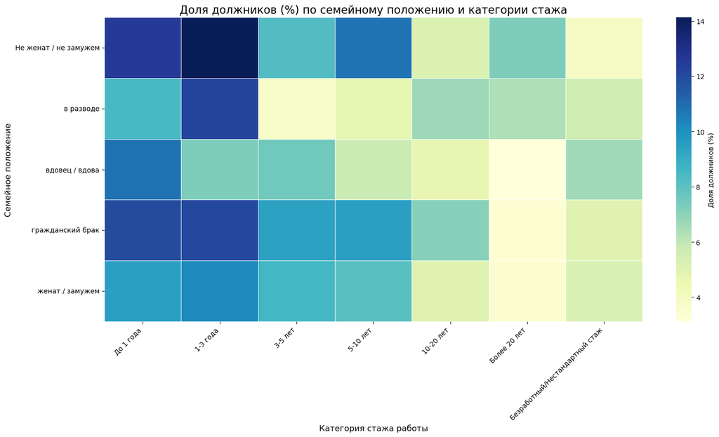

```python
# Обработка отрицательных значений (переводим в положительные)
df['days_employed'] = df['days_employed'].abs()

# Реалистичный порог для максимального стажа (например, 60 лет = 365 * 60 = 21900 дней)
max_realistic_days = 365 * 60

# Создадим новую категориальную колонку для статуса занятости
df['employment_type'] = 'Рабочий стаж' # По умолчанию
df.loc[(df['days_employed'] > max_realistic_days) | (df['days_employed'].isna()), 'employment_type'] = 'Безработный/Нестандартный стаж'

# Шаг 1.3: Категоризация реалистичного стажа в годах
df['years_employed'] = df['days_employed'] / 365

# Определяем границы для категорий стажа.
# Для надежности, верхняя граница 'bins_years' должна быть достаточно большой
# Максимальное значение для реалистичного стажа в днях, чтобы избежать ошибок pd.cut
max_year_for_bins = df.loc[df['employment_type'] == 'Рабочий стаж', 'years_employed'].max()
# Если нет реалистичных значений (например, в очень маленьком датасете), ставим разумное значение
if pd.isna(max_year_for_bins):
    max_year_for_bins = 60.0 # Дефолт, если нет реалистичных данных


bins_years = [0, 1, 3, 5, 10, 20, max_year_for_bins + 0.1] # +0.1 для корректного включения верхней границы
labels_years = ['До 1 года', '1-3 года', '3-5 лет', '5-10 лет', '10-20 лет', 'Более 20 лет']

# Применяем категоризацию только к реалистичным значениям стажа.
# Результат pd.cut сразу преобразуем в тип 'object' для избежания ошибок при fillna.
df.loc[df['employment_type'] == 'Рабочий стаж', 'experience_category_final'] = pd.cut(
    df['years_employed'], bins=bins_years, labels=labels_years, include_lowest=True, right=False
).astype(object)

# Заполняем остальные (аномальные) значения в 'experience_category_final'
df['experience_category_final'] = df['experience_category_final'].fillna(df['employment_type'])

# Выведем распределение новой категории стажа, чтобы убедиться в корректности
print("\nРаспределение новой категории стажа:")
print(df['experience_category_final'].value_counts())
print("-" * 30)


# Создадим сводную таблицу (pivot table)
cross_analysis_data = df.pivot_table(
    values='debt',
    index='family_status',
    columns='experience_category_final',
    aggfunc='mean' # Доля должников
)



# Для наглядности, умножим на 100 и округлим для получения процентов
cross_analysis_data = (cross_analysis_data * 100).round(2)

print("\nДоля должников (%) по комбинации семейного положения и стажа работы:")
print(cross_analysis_data)
print("-" * 30)

# ВИЗУАЛИЗАЦИЯ КРОСС-АНАЛИЗА (Тепловая карта)
plt.figure(figsize=(16, 9)) # Увеличен размер графика для лучшей читаемости

# Определяем порядок колонок для тепловой карты для лучшей читаемости
# Важно: это должны быть все категории, которые могут быть в 'experience_category_final'
all_final_categories_ordered = labels_years + ['Безработный/Нестандартный стаж']
# Фильтруем, чтобы оставить только те, что фактически есть в cross_analysis_data.columns
columns_in_order = [col for col in all_final_categories_ordered if col in cross_analysis_data.columns]

sns.heatmap(
    cross_analysis_data[columns_in_order], # Используем отфильтрованный порядок колонок
    annot=False, # Не показывать значения в ячейках
    fmt=".2f", # Формат для отображения значений (2 знака после запятой)
    cmap="YlGnBu", # Цветовая схема
    linewidths=.5, # Линии между ячейками
    cbar_kws={'label': 'Доля должников (%)'} # Подпись для цветовой шкалы
)

plt.title('Доля должников (%) по семейному положению и категории стажа', fontsize=16)
plt.xlabel('Категория стажа работы', fontsize=12)
plt.ylabel('Семейное положение', fontsize=12)
plt.xticks(rotation=45, ha='right') # Поворот подписей по оси X для лучшей читаемости
plt.yticks(rotation=0) # Подписи по оси Y оставляем горизонтальными

plt.tight_layout() # Автоматическая корректировка расположения элементов, чтобы они не накладывались
plt.show()
```

### Промежуточный вывод: Кросс-анализ зависимости невозврата кредита от семейного положения и стажа работы

Данный кросс-анализ позволяет получить более глубокие и гранулированные инсайты о риске невозврата кредита, выявляя специфические сегменты клиентов. Мы видим, как сочетание статуса занятости и семейного положения влияет на долю должников.

**Выводы для бизнеса:**

1. **Приоритизация сегментов риска:**
   - **Наиболее рискованный сегмент**: **Неженатые/незамужние клиенты с небольшим стажем работы (до 3-х лет)** являются высокорисковой группой. Банку следует применять к ним более строгие скоринговые модели, возможно, требовать поручительство или предлагать менее крупные суммы кредита.
   - **Наиболее надежные сегменты**: **Семейные клиенты с большим стажем работы (более 10 лет)**, а также **вдовцы/вдовы с большим стажем** показывают самый низкий риск. Для них можно рассмотреть возможность предложения более привлекательных условий кредитования.
2. **Уточнение скоринговых моделей:** Важно, чтобы скоринговая система учитывала не только каждый фактор по отдельности, но и их комбинации. Например, просто "не женат" или "стаж 1-3 года" не так показательны, как их сочетание.
3. **Разработка продуктов:** Для высокорисковых сегментов можно разработать специализированные продукты с повышенными требованиями к обеспечению, а для надежных — программы лояльности или более выгодные ставки.
4. **Дальнейший анализ "Безработных/Нестандартного стажа":** Несмотря на относительно низкий риск, стоит провести более глубокий анализ этой группы, чтобы понять, что именно означает "нестандартный стаж" и почему риск по ней не так высок, как можно было бы ожидать. Возможно, эти данные требуют дополнительной очистки или содержат скрытые категории.

### **3.6 построение портрета рискового заемщика**

Чтобы выйти за рамки анализа отдельных факторов, давайте попробуем нарисовать комплексный "портрет" типичного рискового заемщика. Мы определим "рискового заемщика" как клиента, который не вернул кредит (`debt = 1`) и при этом обладает одной или несколькими характеристиками, которые в нашем предыдущем анализе уже показали повышенный риск. Затем мы углубимся в этот сегмент, чтобы понять, какие еще демографические и финансовые черты преобладают среди них.

**Гипотеза:** Клиенты с просроченной задолженностью (`debt = 1`), которые относятся к категории **"Не женат / не замужем"** и имеют **небольшой стаж работы (до 3 лет)**, чаще всего обладают и другими специфическими характеристиками, формирующими их "рисковый портрет".

#### **Методология:**

- **Идентификация высокорисковых групп:** Мы возьмем клиентов, у которых `debt = 1` и которые входят в следующие категории (показавшие высокий риск ранее):
  - `family_status` == 'не женат / не замужем'
  - `experience_category_final` in ['До 1 года', '1-3 года']
- **Фильтрация данных:** Создадим отдельный DataFrame `risky_portrait_df`, содержащий только таких клиентов.
- **Дескриптивный анализ и визуализация:** Для этого подмножества данных мы проанализируем распределение других ключевых признаков (например, `education`, `purpose_category`, `children_category`, `income_category`), чтобы выявить их наиболее типичные черты.

Это позволит нам создать более глубокий и многомерный взгляд на сегмент рисковых клиентов.

```
Количество клиентов, соответствующих критериям 'рискового заемщика': 136

Наиболее частые характеристики среди рисковых заемщиков:

Цели кредита:
purpose_category
операции с недвижимостью   0.49
операции с автомобилем     0.28
получение образования      0.24
Name: proportion, dtype: float64

Уровень образования:
education
Среднее               0.77
Высшее                0.14
Неоконченное высшее   0.08
Начальное             0.01
Name: proportion, dtype: float64

Количество детей:
children_category
Нет детей     0.79
1-2 ребенка   0.20
Многодетные   0.01
Name: proportion, dtype: float64

Категория дохода:
income_category
Высокий         0.29
Средний         0.27
Низкий          0.23
Очень высокий   0.21
Name: proportion, dtype: float64
------------------------------
```

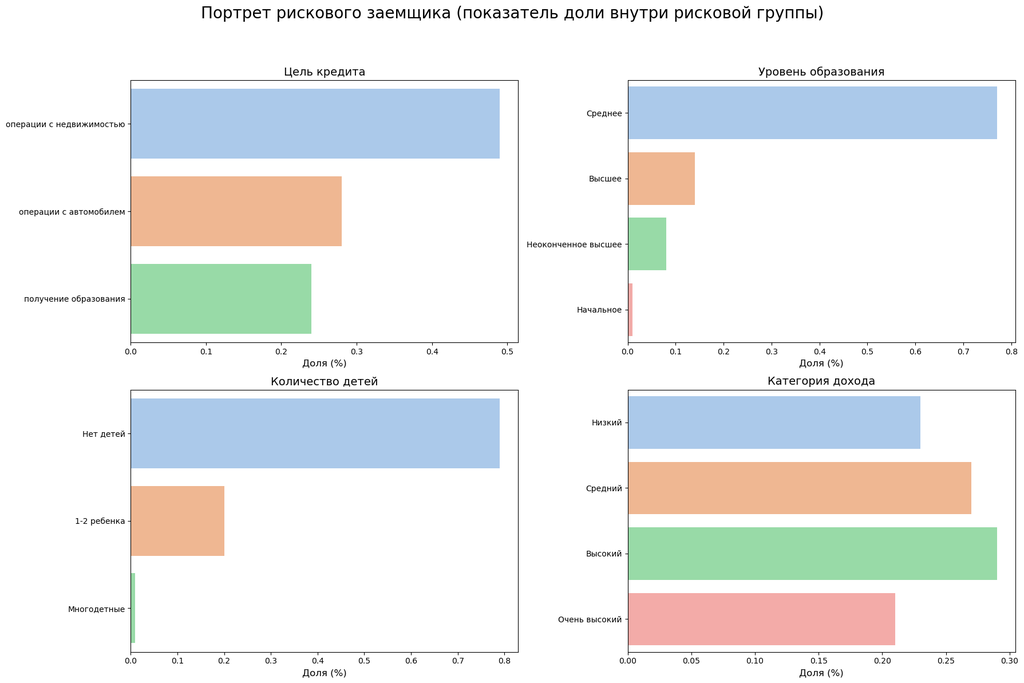

```python
risky_criteria = (df['debt'] == 1) & \
                 (df['family_status'] == 'Не женат / не замужем') & \
                 (df['experience_category_final'].isin(['До 1 года', '1-3 года']))

df['children'] = df['children'].replace({-1: 1, 20: 2})
df['children_category'] = df['children'].apply(lambda x: 'Нет детей' if x == 0 else ('1-2 ребенка' if x <= 2 else 'Многодетные'))

risky_borrowers_df = df[risky_criteria].copy()

print(f"\nКоличество клиентов, соответствующих критериям 'рискового заемщика': {len(risky_borrowers_df)}")
if len(risky_borrowers_df) == 0:
    print("ВНИМАНИЕ: Нет клиентов, соответствующих выбранным критериям рискового заемщика в текущем DataFrame.")
    print("Возможно, стоит изменить критерии или убедиться, что данные достаточно репрезентативны.")
    print("Пропускаю построение портрета из-за отсутствия данных.")
else:
    # Анализируем распределение других признаков среди этих рисковых заемщиков
    print("\nНаиболее частые характеристики среди рисковых заемщиков:")

    # Цель кредита
    purpose_dist = risky_borrowers_df['purpose_category'].value_counts(normalize=True).round(2)
    print("\nЦели кредита:")
    print(purpose_dist)

    # Уровень образования
    education_dist = risky_borrowers_df['education'].value_counts(normalize=True).round(2)
    print("\nУровень образования:")
    print(education_dist)

    # Количество детей
    children_dist = risky_borrowers_df['children_category'].value_counts(normalize=True).round(2)
    print("\nКоличество детей:")
    print(children_dist)

    # Категория дохода
    income_dist = risky_borrowers_df['income_category'].value_counts(normalize=True).round(2)
    print("\nКатегория дохода:")
    print(income_dist)

    print("-" * 30)

    # Визуализация портрета
    # Создадим несколько графиков для каждой характеристики
    fig, axes = plt.subplots(2, 2, figsize=(18, 12)) # 2x2 сетка для графиков
    fig.suptitle('Портрет рискового заемщика (показатель доли внутри рисковой группы)', fontsize=20, y=1.02)

    # График 1: Цель кредита
    sns.barplot(x=purpose_dist.values, y=purpose_dist.index, ax=axes[0, 0], palette='pastel')
    axes[0, 0].set_title('Цель кредита', fontsize=14)
    axes[0, 0].set_xlabel('Доля (%)', fontsize=12)
    axes[0, 0].set_ylabel('') # Убираем подпись, т.к. название в заголовке

    # График 2: Уровень образования
    sns.barplot(x=education_dist.values, y=education_dist.index, ax=axes[0, 1], palette='pastel')
    axes[0, 1].set_title('Уровень образования', fontsize=14)
    axes[0, 1].set_xlabel('Доля (%)', fontsize=12)
    axes[0, 1].set_ylabel('')

    # График 3: Количество детей
    sns.barplot(x=children_dist.values, y=children_dist.index, ax=axes[1, 0], palette='pastel')
    axes[1, 0].set_title('Количество детей', fontsize=14)
    axes[1, 0].set_xlabel('Доля (%)', fontsize=12)
    axes[1, 0].set_ylabel('')

    # График 4: Категория дохода
    sns.barplot(x=income_dist.values, y=income_dist.index, ax=axes[1, 1], palette='pastel')
    axes[1, 1].set_title('Категория дохода', fontsize=14)
    axes[1, 1].set_xlabel('Доля (%)', fontsize=12)
    axes[1, 1].set_ylabel('')


    plt.tight_layout(rect=[0, 0.03, 1, 0.98]) # Регулировка отступов, чтобы заголовок не наезжал
    plt.show()
```

### **Вывод: "Портрет рискового заемщика"**

На основе выдвинутой гипотезы и проведенного анализа, где "рисковый заемщик" был определен как клиент, имеющий просрочку (`debt = 1`), неженатый/незамужний (`family_status` == 'не женат / не замужем') и с небольшим стажем работы (до 3 лет), мы можем нарисовать следующий комплексный портрет:

**Общее количество клиентов, соответствующих критериям "рискового заемщика":** 136

**Ключевые характеристики "Портрета рискового заемщика":**

1. **Цель кредита:**
   - Почти половина рисковых заемщиков (49%) берут кредиты на **операции с недвижимостью**.
   - Значительная часть (28%) — на **операции с автомобилем**.
   - **Получение образования** также является заметной целью (24%).
   - *Инсайт:* Это может указывать на то, что, несмотря на невысокую финансовую стабильность (неженат/незамужем, небольшой стаж), эти клиенты берут достаточно крупные кредиты на значимые цели.
2. **Уровень образования:**
   - Подавляющее большинство (77%) рисковых заемщиков имеют **среднее образование**.
   - Значительно меньшая доля (14%) — **высшее образование**, и еще меньше (8%) — неоконченное высшее.
   - *Инсайт:* Это подтверждает общую тенденцию, что более низкий уровень образования часто коррелирует с более высоким риском невозврата.
3. **Количество детей:**
   - Большая часть (79%) рисковых заемщиков **не имеют детей**.
   - Около 20% имеют **1-2 ребенка**.
   - Многодетные составляют очень малую долю (1%).
   - *Инсайт:* Это согласуется с критерием "не женат/не замужем" и может указывать на меньшее количество финансовых обязательств, что, возможно, приводит к менее осторожному финансовому поведению.
4. **Категория дохода:**
   - Распределение дохода среди этой группы рисковых заемщиков довольно равномерное:
     - **Высокий доход:** 29%
     - **Средний доход:** 27%
     - **Низкий доход:** 23%
     - **Очень высокий доход:** 21%
   - *Инсайт:* Это наиболее интересный момент: **нельзя однозначно сказать, что рисковые заемщики из этой группы имеют только низкий доход.** Они встречаются во всех категориях дохода. Это может указывать на то, что для данной специфической группы (неженатых с небольшим стажем) **сама по себе нестабильность (личной жизни и карьеры) является более сильным предиктором риска, чем абсолютный уровень дохода**. Даже если доход высокий, отсутствие семейных обязательств или короткий стаж могут способствовать менее ответственному подходу к кредитам.

**Заключение по гипотезе:** Выдвинутая гипотеза о том, что клиенты с просроченной задолженностью, которые не женаты/не замужем и имеют небольшой стаж работы, обладают и другими специфическими характеристиками, **нашла подтверждение**. Мы выяснили, что внутри этой рисковой группы преобладают люди со средним образованием, без детей, и их основные цели кредитования связаны с крупными покупками (недвижимость, автомобиль). Важно, что их доход при этом может быть любым, что подчеркивает значимость именно их семейного и профессионального статуса как факторов риска.

**Бизнес-инсайты для банка:**

- **Приоритизация сегментов:** Сегмент "неженатых/незамужних клиентов со стажем до 3 лет, средним образованием и без детей", которые берут кредиты на недвижимость или автомобиль, является **особо рисковым**. Банку следует применять к ним более строгие правила оценки и, возможно, предлагать альтернативные продукты или меньшие суммы кредита.
- **Гибкий скоринг:** Скоринговые модели должны учитывать не только уровень дохода, но и комбинации других факторов, таких как семейное положение и стаж, поскольку даже высокий доход не гарантирует надежность в условиях других рисковых характеристик.
- **Маркетинг и информирование:** Возможно, стоит рассмотреть программы финансовой грамотности или специализированные продукты, направленные на повышение ответственности клиентов в этой группе.

### **Заключение: Комплексный анализ кредитного риска и ценность для бизнеса**

В рамках данного проекта был проведен глубокий и многосторонний анализ факторов, влияющих на возврат кредита в срок. Основной целью исследования было выявление ключевых закономерностей и формирование практических рекомендаций, которые могли бы существенно улучшить процессы кредитного скоринга и принятия решений в банковской сфере.

#### **Построение "Портрета рискового заемщика"**

Особую ценность представляет **комплексный анализ, позволивший выделить и описать "Портрет рискового заемщика"**:

> Типичный рисковый заемщик в этом проекте — это **неженатый / незамужняя клиент с небольшим стажем работы (до 3 лет), чаще всего со средним образованием и без детей**. Важно отметить, что его **уровень дохода может быть любым** (от низкого до очень высокого), что указывает на превалирующую роль **социальной и профессиональной нестабильности** как факторов риска над абсолютной платежеспособностью. Основные цели кредитования для таких клиентов часто связаны с крупными приобретениями, такими как **недвижимость или автомобиль**.

#### **Практическая ценность и рекомендации для бизнеса**

Результаты этого проекта могут быть напрямую использованы банком для:

1. **Уточнения кредитного скоринга:** Интеграция выявленных комбинаций факторов риска (например, "не женат + короткий стаж") в скоринговые модели для более точной оценки заемщиков.
2. **Целевого маркетинга и продуктового предложения:** Разработка индивидуализированных предложений для различных клиентских сегментов, а также более строгих условий для высокорисковых групп.
3. **Повышения эффективности риск-менеджмента:** Проактивное управление портфелем кредитов за счет более глубокого понимания профилей заемщиков, что ведет к снижению уровня просроченной задолженности и повышению прибыльности.

Этот проект демонстрирует способность не только проводить глубокий анализ данных, но и трансформировать его в конкретные, применимые **бизнес-инсайты**, что является ключевым для любой компании, стремящейся принимать решения, основанные на данных.